# Training files vs LocoHub rebuilds, column by column

**What this is.** For each signal the ankle model reads, how far the number in the training file is from the same sample in the rebuilt LocoHub data. Descriptive only: the “reporting sizes” (2°, 20°/s, 0.05 Nm/kg, 0.05 BW, 0.02 m) only decide which differences are counted in the last column. They are not quality limits, and nothing here approves or rejects either file. Differences are *training minus LocoHub*. Unreviewed.

## Headline

- **Ankle moment and vertical force match.** GT21 ankle moment: RMS difference 2.97e-14 Nm/kg over 5,630,728 samples; GT21 vertical force RMS 0.00333 BW. UM21 ankle moment RMS 5.64e-15 Nm/kg (the training value is read between 100 Hz frames).
- **Angles differ, and for some participants by whole turns.** GT21 ankle angle averages -10.6° apart (RMS 17°), shank 2.79° (RMS 12.3°), foot -7.81° (RMS 18.1°). Where the RMS is far above the mean (for example AB24, AB07, AB16), a read-only look at AB24 found training angles near ±350° against LocoHub angles within ±30° (section 3); section 7 separates such wrapped samples from the remaining offsets (they are only a small share of samples). UM21 angles are much closer: 3.33°, -2.57°, 0.789° mean difference.
- **Velocity and centre of pressure** differ by method and origin (see caveats).

## 1. GT21 (training time file against rb07 exports)

15 participants. Pooling: counts, coverage, mean, RMS and share past the reporting size are exact over all matched samples. Correlation and 95th percentile are shown as the median over participants of each participant's own value, with the range in brackets (they cannot be pooled from per-participant summaries).

| Column (unit) | Matched samples | Coverage: training / LocoHub | Mean difference | RMS difference | 95th percentile of \|difference\| | Correlation | Past the reporting size |
| --- | --- | --- | --- | --- | --- | --- | --- |
| Ankle angle (deg) | 6,642,560 | 100.0% / 97.8% | -10.6 | 17 | 14.9 (11.2 to 19.2) | 0.933 (0.294 to 0.981) | 98.6% (> 2 deg) |
| Shank angle (deg) | 6,642,765 | 100.0% / 97.8% | 2.79 | 12.3 | 14.8 (11.5 to 21.6) | 0.953 (0.757 to 0.974) | 83.0% (> 2 deg) |
| Foot angle (deg) | 6,644,623 | 100.0% / 97.9% | -7.81 | 18.1 | 18 (9.95 to 25.4) | 0.933 (0.542 to 0.98) | 87.2% (> 2 deg) |
| Ankle velocity (deg/s) | 6,592,387 | 99.9% / 97.2% | -0.0677 | 66.6 | 121 (86.7 to 146) | 0.845 (0.774 to 0.887) | 52.2% (> 20 deg/s) |
| Ankle moment (Nm/kg) | 5,630,728 | 82.9% / 83.0% | -1.97e-17 | 2.97e-14 | 3.95e-14 (2.20e-14 to 5.00e-14) | 1 (1 to 1) | 0.0% (> 0.05 Nm/kg) |
| Vertical force (BW) | 5,662,174 | 83.5% / 83.4% | -4.85e-05 | 0.00333 | 4.86e-08 (4.38e-08 to 5.23e-08) | 1 (1 to 1) | 0.1% (> 0.05 BW) |
| Centre of pressure, forward (m) | 2,688,738 | 40.2% / 39.8% | 0.0115 | 0.0213 | 0.0368 (0.0169 to 0.0682) | 0.97 (0.947 to 0.986) | 19.7% (> 0.02 m) |

### Per participant, mean difference / RMS

| Participant | Ankle angle bias / RMS (deg) | Shank angle bias / RMS (deg) | Foot angle bias / RMS (deg) | Ankle velocity bias / RMS (deg/s) | Ankle moment bias / RMS (Nm/kg) | Vertical force bias / RMS (BW) | CoP forward bias / RMS (m) |
| --- | --- | --- | --- | --- | --- | --- | --- |
| AB06 | -12 / 12.2 | 9.69 / 10.9 | -2.29 / 5.44 | -0.107 / 47 | 9.61e-18 / 3.54e-14 | -1.20e-05 / 0.00345 | 0.00342 / 0.0159 |
| AB07 | -10.5 / 19.5 | 0.331 / 19 | -10.1 / 28.2 | -0.0814 / 59.1 | -6.12e-17 / 3.48e-14 | -7.24e-05 / 0.00463 | 0.0169 / 0.028 |
| AB08 | -10.9 / 18.3 | 6.19 / 13 | -4.72 / 16.7 | -0.361 / 64.7 | -5.17e-17 / 3.29e-14 | -1.37e-04 / 0.00264 | 0.00481 / 0.0164 |
| AB09 | -11.4 / 18.1 | 6.28 / 8.86 | -5.09 / 13.3 | -0.0721 / 71 | -5.99e-18 / 2.59e-14 | 2.15e-04 / 0.00348 | 0.00504 / 0.0127 |
| AB10 | -7.73 / 8.18 | 0.672 / 5.7 | -7.05 / 8.81 | -0.0709 / 72.8 | 3.31e-17 / 3.11e-14 | -1.64e-04 / 0.0024 | 0.0111 / 0.0166 |
| AB11 | -13.3 / 16.1 | 5.77 / 8.57 | -7.57 / 11.7 | -0.112 / 53.5 | -8.31e-17 / 2.11e-14 | 9.79e-06 / 0.00154 | 0.0129 / 0.0208 |
| AB13 | -6.01 / 7.02 | -3.67 / 6.23 | -9.69 / 11.1 | -0.481 / 62 | -3.88e-19 / 2.94e-14 | 5.67e-05 / 0.00261 | 0.015 / 0.0217 |
| AB14 | -11.9 / 12.2 | 11.5 / 12.7 | -0.376 / 5.17 | 0.165 / 69.4 | 1.33e-17 / 2.78e-14 | 1.70e-05 / 0.00307 | 0.00165 / 0.00904 |
| AB16 | -12.1 / 24.7 | 0.883 / 14.6 | -11.2 / 24.9 | -0.205 / 71.5 | -6.16e-17 / 2.72e-14 | 3.03e-05 / 0.00376 | 0.016 / 0.0261 |
| AB18 | -8.75 / 13.5 | -4.1 / 8.5 | -12.8 / 15.8 | 0.187 / 71.1 | 1.74e-17 / 2.81e-14 | -5.67e-05 / 0.00276 | 0.0215 / 0.0277 |
| AB20 | -12.7 / 13.2 | 6.43 / 9.54 | -6.27 / 9.08 | 0.182 / 65 | 5.62e-18 / 2.84e-14 | 2.32e-05 / 0.00152 | 0.0077 / 0.0141 |
| AB21 | -15.1 / 15.4 | 12.4 / 13.5 | -2.73 / 5.65 | -0.0159 / 80.6 | -3.37e-17 / 3.14e-14 | -2.39e-04 / 0.00446 | 0.00261 / 0.0105 |
| AB24 | -10.1 / 35.7 | -5.29 / 18.2 | -15.4 / 40.9 | 0.233 / 75.3 | 1.99e-18 / 2.70e-14 | 1.03e-04 / 0.00239 | 0.0243 / 0.0339 |
| AB25 | -8.05 / 8.32 | -3.86 / 16.2 | -11.9 / 19.8 | 0.0385 / 61.7 | -5.98e-18 / 2.98e-14 | -3.54e-04 / 0.00557 | 0.0189 / 0.0266 |
| AB30 | -8.27 / 9.2 | -0.348 / 6.88 | -8.61 / 11.9 | -0.236 / 73.3 | -5.29e-17 / 3.08e-14 | -1.49e-04 / 0.00245 | 0.00907 / 0.0187 |

## 2. UM21 (training time file against package v4 phase file)

10 participants, treadmill only, right leg; samples are LocoHub phase samples (150 per stride) with the training series read at the same source-time positions. Pooled directly (one job).

[output not shown]

### Per participant, mean difference / RMS

| Participant | Ankle angle bias / RMS (deg) | Shank angle bias / RMS (deg) | Foot angle bias / RMS (deg) | Ankle velocity bias / RMS (deg/s) | Ankle moment bias / RMS (Nm/kg) | Vertical force bias / RMS (BW) | CoP forward bias / RMS (m) |
| --- | --- | --- | --- | --- | --- | --- | --- |
| AB01 | 2.09 / 2.24 | -1.6 / 1.7 | 0.498 / 0.786 | – | 5.25e-17 / 6.14e-15 | – | 0.0233 / 0.0302 |
| AB02 | 1.17 / 1.81 | -1.69 / 1.77 | -0.518 / 1.51 | – | 5.81e-18 / 5.83e-15 | – | 0.00599 / 0.0137 |
| AB03 | 6.4 / 6.71 | -6.83 / 6.95 | -0.427 / 1.94 | – | -7.36e-18 / 4.77e-15 | – | 0.00282 / 0.0262 |
| AB04 | 7.14 / 7.22 | -2.47 / 2.56 | 4.67 / 4.73 | – | -3.85e-17 / 6.98e-15 | – | 0.00665 / 0.0266 |
| AB05 | 3.2 / 3.46 | -0.236 / 1.23 | 2.91 / 3.2 | – | -3.50e-17 / 4.58e-15 | – | 0.0333 / 0.0365 |
| AB06 | 4.07 / 4.26 | -2.62 / 2.85 | 1.44 / 2.47 | – | -5.70e-19 / 6.08e-15 | – | 0.0129 / 0.018 |
| AB07 | 2.45 / 2.85 | -2.92 / 3.11 | -0.458 / 1.37 | – | -6.31e-18 / 5.52e-15 | – | 0.0129 / 0.0199 |
| AB08 | 1.94 / 2.46 | -3.2 / 3.37 | -1.25 / 2.42 | – | -4.18e-17 / 5.53e-15 | – | 0.0118 / 0.0172 |
| AB09 | 3.58 / 3.67 | -3.64 / 3.91 | -0.063 / 1.75 | – | 3.48e-17 / 6.25e-15 | – | 0.0227 / 0.0249 |
| AB10 | 0.488 / 1.78 | 0.314 / 1.69 | 0.802 / 1.41 | – | -1.10e-17 / 4.97e-15 | – | 0.00253 / 0.0141 |

## Figures

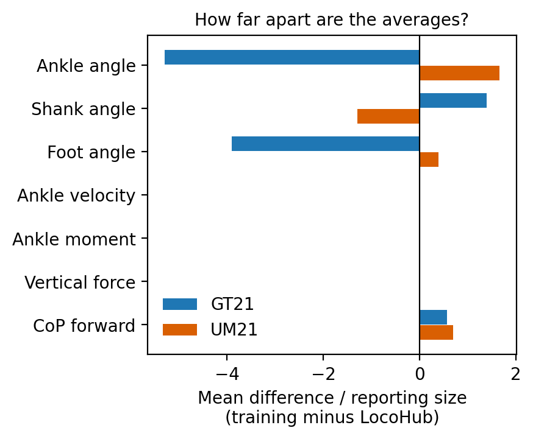

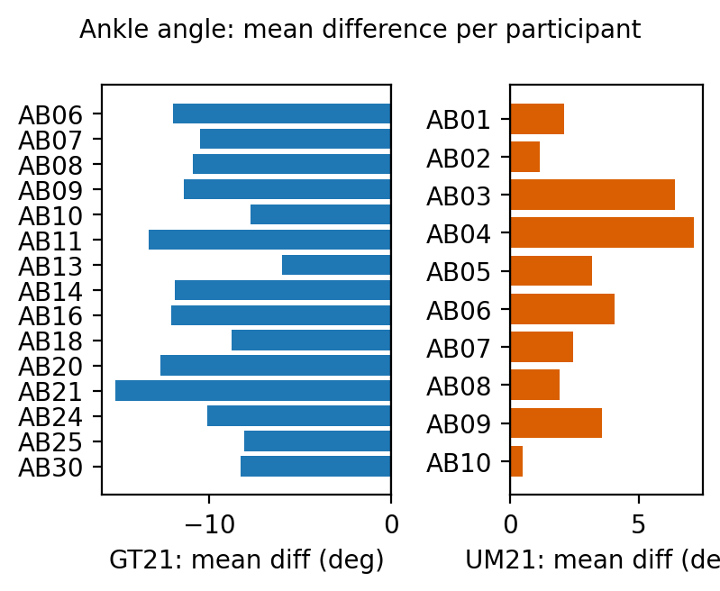

Figure 1: mean difference divided by each column's reporting size (training minus LocoHub). Figure 2: ankle angle mean difference per participant, same sign convention.

## 3. Biggest differences by participant and task

Ranked by RMS divided by the reporting size, among participant-and-task groups with at least 1,000 matched samples. Task is the training file's own label.

**Why AB24 tops the list.** A read-only probe of AB24 (output: `docs/quality/audits/training-compare-probe-ab24-angle-range.txt`) compared the eight AB24 recordings with the largest ankle-angle RMS and two typical ones. In the eight, the training ankle angle lies in roughly −445 to −343° or 286 to 395° while the LocoHub angle lies in about −26 to 24°; foot angle is similarly out by about 180° or 360° in most of them. The two typical recordings differ by about 13° (ankle) and 19° (foot) with both series in a normal range. This probe covers AB24 only; section 7 applies a fixed rule to every compared recording and separates wrapped samples from real offsets.

### GT21

| Participant | Task (training label) | Column | Matched samples | Mean difference | RMS difference | RMS / reporting size |
| --- | --- | --- | --- | --- | --- | --- |
| AB24 | decline_walking | Foot angle (deg) | 32,734 | -13.2 | 81.2 | 40.6 |
| AB24 | decline_walking | Ankle angle (deg) | 31,944 | -7.13 | 71.5 | 35.7 |
| AB07 | stair_descent | Foot angle (deg) | 13,196 | -3.62 | 51.9 | 26.0 |
| AB24 | transition | Foot angle (deg) | 95,248 | -12.1 | 50.8 | 25.4 |
| AB24 | transition | Ankle angle (deg) | 94,947 | -8.07 | 45.7 | 22.9 |
| AB24 | incline_walking | Foot angle (deg) | 36,060 | -3.85 | 45.2 | 22.6 |
| AB24 | incline_walking | Ankle angle (deg) | 36,060 | -4.91 | 41.2 | 20.6 |
| AB24 | decline_walking | Shank angle (deg) | 31,944 | -6.01 | 40 | 20.0 |
| AB07 | stair_descent | Shank angle (deg) | 13,196 | 3.62 | 36.8 | 18.4 |
| AB18 | stair_descent | Ankle angle (deg) | 12,034 | -11.4 | 33 | 16.5 |

### UM21

| Participant | Task (training label) | Column | Matched samples | Mean difference | RMS difference | RMS / reporting size |
| --- | --- | --- | --- | --- | --- | --- |
| AB04 | decline_walking | Ankle angle (deg) | 23,700 | 7.41 | 7.48 | 3.7 |
| AB03 | incline_walking | Ankle angle (deg) | 21,450 | 7.05 | 7.35 | 3.7 |
| AB03 | level_walking | Shank angle (deg) | 10,650 | -7.17 | 7.3 | 3.6 |
| AB03 | decline_walking | Shank angle (deg) | 22,950 | -7.07 | 7.18 | 3.6 |
| AB04 | transition | Ankle angle (deg) | 4,950 | 6.97 | 7.04 | 3.5 |
| AB03 | transition | Shank angle (deg) | 6,600 | -6.88 | 7 | 3.5 |
| AB04 | incline_walking | Ankle angle (deg) | 18,300 | 6.84 | 6.92 | 3.5 |
| AB03 | incline_walking | Shank angle (deg) | 21,450 | -6.39 | 6.5 | 3.3 |
| AB03 | level_walking | Ankle angle (deg) | 10,650 | 6.15 | 6.43 | 3.2 |
| AB03 | decline_walking | Ankle angle (deg) | 22,950 | 6.08 | 6.37 | 3.2 |

## 4. Alignment

Training and LocoHub clocks are not assumed equal. Each training recording is matched to a LocoHub recording by name, then shifted in time by cross-correlating the ankle moment (exact moment difference over all shifts, both signs); a pair counts only if the best moment RMS is at most 0.10 Nm/kg over at least 100 samples (and 30% of the training moment samples). The tolerance only decides whether two recordings are the same recording.

### GT21

- Training recordings found in the files: 8,458; matched to a LocoHub recording: **7,886** (98.3% of training rows).
- Largest moment difference among matched pairs: 2.02e-13 Nm/kg (alignment tolerance 0.10 Nm/kg). Sign of best fit: {'same': 7886}.
- Reference leg chosen by best fit (the training file does not keep it): {'left': 1602, 'right': 6284}.
- Training recordings not compared: 568 – alignment impossible: too little overlapping moment.
- Training recordings not compared: 4 – no finite ankle moment in the training recording.

### Alignment failures

16 of the 19 UM21 failures are the short `d0x5` segments (about 550 training rows each) 2 are `a0x5` and 1 is `d0x2`; they have the least moment data to align on. They are left out of the statistics, not forced to match.

**GT21:**

None.

**UM21:**

| Participant | Training recording | Best moment RMS (Nm/kg) | Overlap (samples) | Training rows |
| --- | --- | --- | --- | --- |
| AB01 | Tread_i10_d0x5_seg07 | 0.252 | 271 | 549 |
| AB09 | Tread_i5_d0x5_seg07 | 0.201 | 222 | 553 |
| AB04 | Tread_i5_d0x5_seg07 | 0.196 | 224 | 561 |
| AB10 | Tread_i10_d0x2_seg06 | 0.192 | 224 | 1255 |
| AB03 | Tread_d10_d0x5_seg07 | 0.181 | 209 | 549 |
| AB10 | Tread_i10_d0x5_seg07 | 0.176 | 108 | 559 |
| AB02 | Tread_i10_d0x5_seg07 | 0.173 | 189 | 555 |
| AB07 | Tread_i5_d0x5_seg07 | 0.159 | 248 | 553 |
| AB06 | Tread_i10_a0x5_seg05 | 0.149 | 106 | 551 |
| AB04 | Tread_i10_d0x5_seg07 | 0.149 | 192 | 549 |
| AB10 | Tread_i5_d0x5_seg07 | 0.147 | 112 | 551 |
| AB01 | Tread_i0_d0x5_seg07 | 0.139 | 100 | 565 |
| AB09 | Tread_d10_d0x5_seg07 | 0.137 | 136 | 565 |
| AB05 | Tread_i10_d0x5_seg07 | 0.133 | 168 | 561 |
| AB07 | Tread_d10_d0x5_seg07 | 0.132 | 274 | 547 |
| AB05 | Tread_d5_d0x5_seg07 | 0.128 | 100 | 561 |
| AB05 | Tread_i0_d0x5_seg07 | 0.123 | 275 | 549 |
| AB06 | Tread_i5_a0x5_seg05 | 0.113 | 101 | 547 |
| AB03 | Tread_i10_d0x5_seg07 | 0.106 | 104 | 543 |

## 5. Columns compared and not compared

| Column | Training | LocoHub | Reporting size |
| --- | --- | --- | --- |
| Ankle angle | `ankle_dorsiflexion_angle_ipsi_rad` | `ankle_dorsiflexion_angle_{R}_rad` | 2 deg |
| Shank angle | `shank_sagittal_angle_ipsi_rad` | `shank_sagittal_angle_{R}_rad` | 2 deg |
| Foot angle | `foot_sagittal_angle_ipsi_rad` | `foot_sagittal_angle_{R}_rad` | 2 deg |
| Ankle velocity | `dtheta_raw` | `ankle_dorsiflexion_velocity_{R}_rad_s` | 20 deg/s |
| Ankle moment | `ankle_dorsiflexion_moment_ipsi_Nm_kg` | `ankle_dorsiflexion_moment_{R}_Nm_kg` | 0.05 Nm/kg |
| Vertical force | `grf_vertical_ipsi_BW` | `grf_vertical_{R}_BW` | 0.05 BW |
| Centre of pressure, forward | `cop_anterior_ipsi_m` | `cop_anterior_{R}_m` | 0.02 m |

Training columns not compared (same list for both files):

| `recording_id` | key (subject \| collection_id, joins marked +k) |
| --- | --- |
| `subject` | key |
| `dataset` | constant label |
| `task` | group label (reporting only) |
| `task_id` | label, not read |
| `task_info` | label text, not read |
| `step` | training step counter, not read |
| `time_s` | time key |
| `dt_s` | constant 0.005, not read |
| `dpsi_raw` | training backward difference of shank angle; LocoHub GT21 and UM21 have no shank speed column |
| `dphi_raw` | training backward difference of foot angle; LocoHub has no foot speed column |
| `dtheta_f15` | training 15 Hz low-pass of dtheta_raw (training-only derived signal) |
| `dpsi_f15` | training 15 Hz low-pass of dpsi_raw (training-only derived signal) |
| `swing` | training mask |
| `wc_weight` | training weight |
| `window_ok` | training mask |
| `loss_mask` | training mask |

LocoHub columns not compared (hip, knee, thigh, pelvis, power, lateral and anterior forces, held signals) are listed in each `summary.json` under `mapping.locohub_unmapped`. LocoHub UM21 package v4 (phase only) has no ankle velocity or vertical force column, so those two rows have no matched samples.

## 6. Caveats

- **Velocity** in the training file is its own backward difference of the sampled angle; LocoHub uses the source or stride slope. The difference is a method difference.
- **Centre of pressure**: the LocoHub value has the 0.100 m origin shift added back before comparing, so the mean difference also contains any difference between the two ankle-centre definitions. It is only present where force was measured.
- **UM21 package v4, the one compared here, has no LocoHub force and no time table**; comparisons use LocoHub phase samples only. Package v5 adds a time table with force and was not compared.
- **Angles**: the training UM21 shank/foot values include its own −2× pelvis tilt correction; the training GT21 values were built on the old pelvis tilt, and the angle zero differs between the two (static pose vs gravity).
- **Coverage** is the fraction of compared positions with a value in each series; a missing value in either series removes that sample from every statistic of that column.
- Training recordings with too little finite ankle moment to align are listed, not compared; every skipped recording is counted in section 4.
- GT21 jobs were run two participants at a time (wrap analysis in section 7: one participant per job) to stay under the memory cap; pooled values merge those jobs. Reconstructed from `docs/quality/audits/training-compare-*`.

## 7. Wrap errors vs real offsets

**Summary.** In GT21, 0.1% of matched ankle-angle samples, 0.2% of shank and 0.2% of foot samples are wrapped under the rule below. Removing them changes the ankle mean difference from -10.6° to -10.6° and the RMS from 17° to 14.8°; wraps are therefore a small part of the pooled numbers (a few recordings, mostly AB24, AB07, AB16 and AB25); what is left after removing them is a difference between the two files that is not a wrap. UM21 has no wrapped samples. 44 of 8,145 compared training recordings have at least one wrapped sample (participants: AB07 (8), AB08 (5), AB09 (3), AB11 (1), AB16 (5), AB18 (2), AB24 (14), AB25 (4), AB30 (2)).

**Rule (fixed in advance, not tuned to reach any result).** A matched angle sample is called "wrapped" when the training value is more than 90 degrees away from the LocoHub value AND the difference (training minus LocoHub) is within 20 degrees of a multiple of 180 degrees. Multiples that are even (0, 360, 720 ...) are "whole-turn wraps"; odd multiples (180, 540 ...) are "half-turn flips". Corrected value = training value minus that multiple of 180 degrees. Both numbers (90 and 20) were fixed in advance, not tuned. Velocity: the ankle-angle wrap flags are widened by 2 samples on each side and velocity samples inside the widened flags are left out (neighbours are neighbours in the compared sample order; for UM21 this also reaches across stride joins).

Pooling is the same as above: GT21 mean, RMS and share past 2° are exact over all matched samples; correlation and 95th percentile are the median over participants (range in brackets; the percentile of each participant comes from a histogram with 0.01° bins, so it is approximate). UM21 is one job. Source: `wrap_stats.csv`, `wrap_counts.csv` and `wrap_recordings.csv` in `docs/quality/audits/training-compare-wrap-gt21-AB*/` and `training-compare-wrap-um21/`.

### GT21 angles

| Column | Wrapped share of matched samples | Samples used | Mean difference (deg) | RMS difference (deg) | 95th percentile of \|difference\| (deg) | Correlation | Past 2 deg |
| --- | --- | --- | --- | --- | --- | --- | --- |
| Ankle angle | 0.1% (3,706 of 6,642,560; 3,560 whole-turn, 146 half-turn) | All samples: 6,642,560 | -10.6 | 17 | 14.9 (11.2 to 19.2) | 0.933 (0.294 to 0.981) | 98.6% |
|  |  | Wrapped samples removed: 6,638,854 | -10.6 | 14.8 | 14.9 (11.2 to 19.2) | 0.933 (0.448 to 0.981) | 98.6% |
|  |  | Whole turns corrected (half-turn flips left out): 6,642,414 | -10.6 | 14.8 | 14.9 (11.2 to 19.2) | 0.933 (0.448 to 0.981) | 98.6% |
|  |  | Whole turns and half turns corrected: 6,642,560 | -10.6 | 14.8 | 14.9 (11.2 to 19.2) | 0.933 (0.448 to 0.981) | 98.6% |
| Shank angle | 0.2% (11,746 of 6,642,765; 498 whole-turn, 11,248 half-turn) | All samples: 6,642,765 | 2.79 | 12.3 | 14.8 (11.5 to 21.6) | 0.953 (0.757 to 0.974) | 83.0% |
|  |  | Wrapped samples removed: 6,631,019 | 2.64 | 9.4 | 14.8 (11.5 to 21.6) | 0.962 (0.866 to 0.974) | 83.0% |
|  |  | Whole turns corrected (half-turn flips left out): 6,631,517 | 2.64 | 9.4 | 14.8 (11.5 to 21.6) | 0.962 (0.866 to 0.974) | 83.0% |
|  |  | Whole turns and half turns corrected: 6,642,765 | 2.63 | 9.39 | 14.8 (11.5 to 21.6) | 0.962 (0.867 to 0.974) | 83.0% |
| Foot angle | 0.2% (14,111 of 6,644,623; 1,971 whole-turn, 12,140 half-turn) | All samples: 6,644,623 | -7.81 | 18.1 | 18 (9.95 to 25.4) | 0.933 (0.542 to 0.98) | 87.2% |
|  |  | Wrapped samples removed: 6,630,512 | -7.98 | 14.7 | 18 (9.95 to 25) | 0.948 (0.73 to 0.98) | 87.2% |
|  |  | Whole turns corrected (half-turn flips left out): 6,632,483 | -7.98 | 14.7 | 18 (9.95 to 25) | 0.948 (0.73 to 0.98) | 87.2% |
|  |  | Whole turns and half turns corrected: 6,644,623 | -7.98 | 14.7 | 18 (9.95 to 25) | 0.948 (0.731 to 0.98) | 87.2% |

### UM21 angles

| Column | Wrapped share of matched samples | Samples used | Mean difference (deg) | RMS difference (deg) | 95th percentile of \|difference\| (deg) | Correlation | Past 2 deg |
| --- | --- | --- | --- | --- | --- | --- | --- |
| Ankle angle | 0.0% (0 of 509,250; 0 whole-turn, 0 half-turn) | All samples: 509,250 | 3.33 | 4.16 | 7.88 | 0.959 | 71.3% |
|  |  | Wrapped samples removed: 509,250 | 3.33 | 4.16 | 7.88 | 0.959 | 71.3% |
|  |  | Whole turns corrected (half-turn flips left out): 509,250 | 3.33 | 4.16 | 7.88 | 0.959 | 71.3% |
|  |  | Whole turns and half turns corrected: 509,250 | 3.33 | 4.16 | 7.88 | 0.959 | 71.3% |
| Shank angle | 0.0% (0 of 509,400; 0 whole-turn, 0 half-turn) | All samples: 509,400 | -2.57 | 3.45 | 7.4 | 0.994 | 61.4% |
|  |  | Wrapped samples removed: 509,400 | -2.57 | 3.45 | 7.4 | 0.994 | 61.4% |
|  |  | Whole turns corrected (half-turn flips left out): 509,400 | -2.57 | 3.45 | 7.4 | 0.994 | 61.4% |
|  |  | Whole turns and half turns corrected: 509,400 | -2.57 | 3.45 | 7.4 | 0.994 | 61.4% |
| Foot angle | 0.0% (0 of 517,500; 0 whole-turn, 0 half-turn) | All samples: 517,500 | 0.789 | 2.43 | 4.79 | 0.996 | 38.7% |
|  |  | Wrapped samples removed: 517,500 | 0.789 | 2.43 | 4.79 | 0.996 | 38.7% |
|  |  | Whole turns corrected (half-turn flips left out): 517,500 | 0.789 | 2.43 | 4.79 | 0.996 | 38.7% |
|  |  | Whole turns and half turns corrected: 517,500 | 0.789 | 2.43 | 4.79 | 0.996 | 38.7% |

### GT21 ankle velocity

| Ankle velocity | Samples used | Mean difference (deg/s) | RMS difference (deg/s) | 95th percentile of \|difference\| (deg/s) | Correlation | Past 20 deg/s |
| --- | --- | --- | --- | --- | --- | --- |
| All samples | 6,592,387 | -0.0677 | 66.6 | 121 (86.7 to 146) | 0.845 (0.774 to 0.887) | 52.2% |
| Samples within 2 of an ankle-angle wrap removed | 6,589,059 | -0.0683 | 66.3 | 121 (86.7 to 146) | 0.846 (0.774 to 0.887) | 52.2% |

### UM21 ankle velocity

| Ankle velocity | Samples used | Mean difference (deg/s) | RMS difference (deg/s) | 95th percentile of \|difference\| (deg/s) | Correlation | Past 20 deg/s |
| --- | --- | --- | --- | --- | --- | --- |
| All samples | no LocoHub velocity to compare |  |  |  |  |  |
| Samples within 2 of an ankle-angle wrap removed | no LocoHub velocity to compare |  |  |  |  |  |

UM21 phase package v4 has no velocity column, so there is nothing to compare there.

### Most affected training recordings (top 20 by wrapped share)

44 recordings in all; ranked by the largest wrapped share of the three angle columns. The full list (one row per recording, with all three columns) is `docs/quality/audits/training-compare-wrap-affected-recordings.csv`. Recordings with a share of 100% are wrapped from start to end; lower shares are wraps that come and go inside a recording.

| Participant | Task (training label) | Training recording | Worst column | Wrapped share (ankle / shank / foot) | Typical offset in the worst column (deg) |
| --- | --- | --- | --- | --- | --- |
| AB07 | level_walking | levelground_levelground_cw_slow_01_05_stand-walk_seg01+1 | Shank angle | 0.0% / 100.0% / 85.6% | -180 |
| AB25 | level_walking | levelground_LevelGround_cw_slow_01_05_walk_seg01 | Foot angle | 0.0% / 100.0% / 100.0% | 169 |
| AB25 | level_walking | levelground_LevelGround_cw_slow_01_05_walk_seg02 | Foot angle | 0.0% / 100.0% / 100.0% | 167 |
| AB07 | level_walking | levelground_levelground_cw_slow_01_05_walk_seg02+1 | Shank angle | 0.0% / 100.0% / 99.1% | -179 |
| AB16 | level_walking | levelground_levelground_cw_normal_01_03_stand-walk_seg01+1 | Shank angle | 0.0% / 100.0% / 99.7% | 176 |
| AB16 | level_walking | levelground_levelground_cw_normal_01_03_walk_seg02 | Foot angle | 0.0% / 100.0% / 100.0% | 175 |
| AB08 | level_walking | levelground_levelground_cw_fast_02_02_walk_seg01 | Foot angle | 0.0% / 100.0% / 100.0% | 178 |
| AB24 | level_walking | levelground_levelground_cw_normal_01_02_walk_seg02 | Ankle angle | 100.0% / 0.0% / 46.0% | -373 |
| AB24 | incline_walking | ramp_ramp_1_l_01_02_rampascent_seg01 | Shank angle | 0.0% / 100.0% / 97.8% | 176 |
| AB08 | level_walking | levelground_levelground_cw_fast_02_02_walk_seg02 | Shank angle | 0.0% / 100.0% / 93.0% | 186 |
| AB08 | transition | levelground_levelground_cw_fast_02_02_stand-walk_seg01 | Foot angle | 0.0% / 100.0% / 100.0% | 179 |
| AB25 | transition | levelground_LevelGround_cw_slow_01_05_stand-walk_seg01 | Foot angle | 0.0% / 100.0% / 100.0% | 170 |
| AB25 | transition | levelground_LevelGround_cw_slow_01_05_walk-stand_seg01 | Foot angle | 0.0% / 100.0% / 100.0% | 164 |
| AB08 | transition | levelground_levelground_cw_fast_02_02_walk-stand_seg01 | Foot angle | 0.0% / 100.0% / 100.0% | 168 |
| AB24 | transition | ramp_ramp_1_l_01_05_rampdescent-walk_seg01 | Ankle angle | 100.0% / 0.0% / 71.2% | 351 |
| AB16 | transition | levelground_levelground_cw_normal_01_03_walk-stand_seg01 | Foot angle | 0.0% / 100.0% / 100.0% | 176 |
| AB24 | transition | ramp_ramp_1_l_01_05_walk-rampdescent_seg01 | Ankle angle | 100.0% / 0.0% / 98.5% | 351 |
| AB24 | transition | ramp_ramp_1_l_01_02_walk-rampdescent_seg01 | Ankle angle | 99.0% / 99.0% / 78.1% | 351 |
| AB24 | decline_walking | ramp_ramp_1_l_01_01_walk-rampdescent_seg01+2 | Ankle angle | 97.2% / 95.6% / 53.2% | -369 |
| AB24 | decline_walking | ramp_ramp_1_l_01_02_rampdescent_seg01+1 | Ankle angle | 97.2% / 87.1% / 53.1% | 350 |